Quinn Ziegler - Univariate Exercises 3

```r
link='https://github.com/EvansDataScience/VisualAnalytics_2_tabularData/raw/master/data/eduwa.rda'

#getting the data TABLE from the file in the cloud:
load(file=url(link))
```

```r
#number of rows and columns
dim(eduwa) #nrow(eduwa) ncol(eduwa)
```

```
## [1] 2427   24
```

This is the list of the 24 columns:

```r
names(eduwa)
```

```
##  [1] "NCES.School.ID"        "State.School.ID"
##  [3] "NCES.District.ID"      "State.District.ID"
##  [5] "Low.Grade"             "High.Grade"
##  [7] "School.Name"           "District"
##  [9] "County"                "Street.Address"
## [11] "City"                  "State"
## [13] "ZIP"                   "ZIP.4-digit"
## [15] "Phone"                 "Locale.Code"
## [17] "LocaleType"            "LocaleSub"
## [19] "Charter"               "Title.I.School"
## [21] "Title.1.School.Wide"   "Student.Teacher.Ratio"
## [23] "Free.Lunch"            "Reduced.Lunch"
```

```r
table(eduwa$High.Grade,exclude = 'nothing')
```

```
##
##  PK  KG   1   2   3   4   5   6   7   8   9  10  11  12  13
##  82   7   6  16  19  45 755 266  11 427  15   7   5 757   9
```

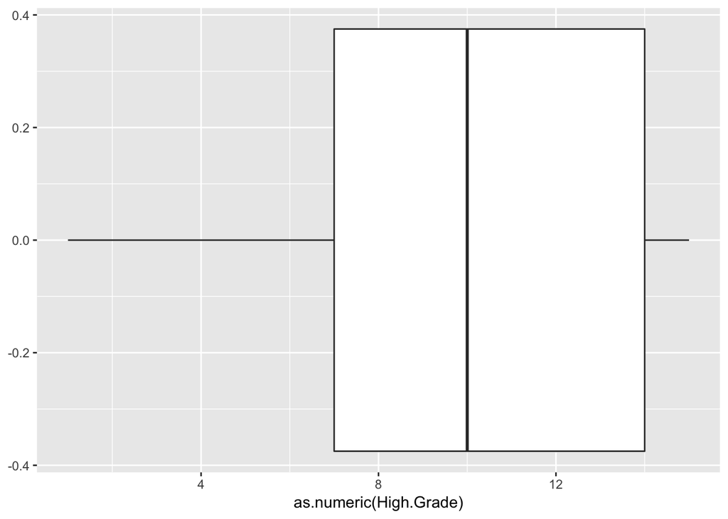

```r
library(ggplot2)
# boxplots do not use frequency tables

# as.numeric produces turns levels of the factor into numbers
box1 = ggplot(eduwa, aes(y=as.numeric(High.Grade)))
box1 = box1 + geom_boxplot() + coord_flip() # to show it horizontally

box1
```

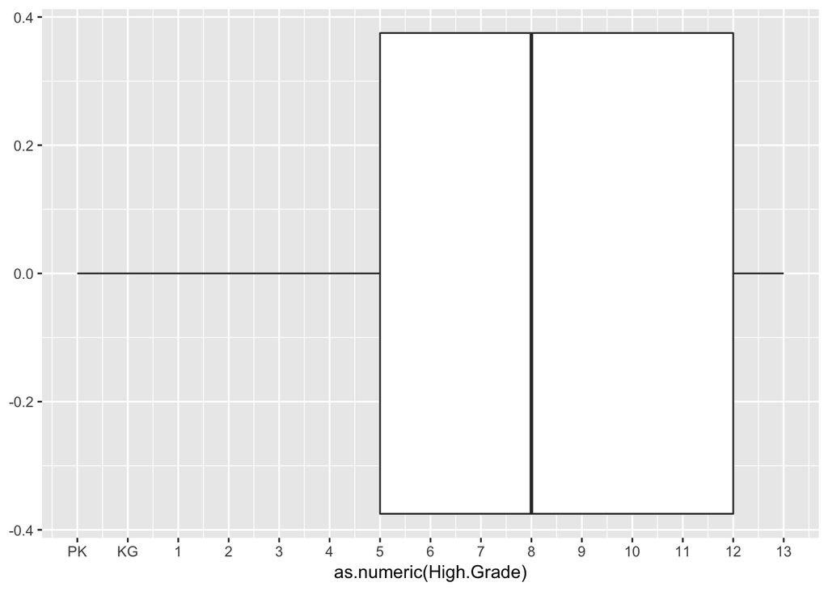

```r
# the labels use the original ordinal levels
ordLabels= levels(eduwa$High.Grade)

box2 = box1 + scale_y_continuous(labels=ordLabels,breaks=1:15)
box2
```

Box plots have important statistical information. The beginning and the ending of the box indicates the first (q1) and the third quantile (q75); and the thicker line in the middle represents the median. All those values are clearly visible, but we can retrieve the values like this:

```r
#get positions
# using 'ggplot_build'
pos_q1=     ggplot_build(box2)$data[[1]]$lower
pos_median= ggplot_build(box2)$data[[1]]$middle
pos_q3=     ggplot_build(box2)$data[[1]]$upper

# using
levels(eduwa$High.Grade)[c(pos_q1,pos_median,pos_q3)]
```

```
## [1] "5"  "8"  "12"
```

From the information retrieved, we know:

- 25% of the public Schools offer at most 5th GRADE.
- 50% of the public Schools offer at most 8th GRADE.
- 75% of the public Schools offer at most 12th GRADE. Also, 25% of the schools offer at least 12th grade.

We can find these results with a *detailed* frequency table; that is, instead of using the command *table* as we did before, we could try a more advanced function:

```r
library(summarytools)
freq(eduwa$High.Grade,style = 'rmarkdown')
```

### Frequencies

**Variable:** eduwa$High.Grade  
**Type:** Factor (ordered)

|  | Freq | % Valid | % Valid Cum. | % Total | % Total Cum. |
| --- | --- | --- | --- | --- | --- |
| **PK** | 82 | 3.38 | 3.38 | 3.38 | 3.38 |
| **KG** | 7 | 0.29 | 3.67 | 0.29 | 3.67 |
| **1** | 6 | 0.25 | 3.91 | 0.25 | 3.91 |
| **2** | 16 | 0.66 | 4.57 | 0.66 | 4.57 |
| **3** | 19 | 0.78 | 5.36 | 0.78 | 5.36 |
| **4** | 45 | 1.85 | 7.21 | 1.85 | 7.21 |
| **5** | 755 | 31.11 | 38.32 | 31.11 | 38.32 |
| **6** | 266 | 10.96 | 49.28 | 10.96 | 49.28 |
| **7** | 11 | 0.45 | 49.73 | 0.45 | 49.73 |
| **8** | 427 | 17.59 | 67.33 | 17.59 | 67.33 |
| **9** | 15 | 0.62 | 67.94 | 0.62 | 67.94 |
| **10** | 7 | 0.29 | 68.23 | 0.29 | 68.23 |
| **11** | 5 | 0.21 | 68.44 | 0.21 | 68.44 |
| **12** | 757 | 31.19 | 99.63 | 31.19 | 99.63 |
| **13** | 9 | 0.37 | 100.00 | 0.37 | 100.00 |
| **<NA>** | 0 |  |  | 0.00 | 100.00 |
| **Total** | 2427 | 100.00 | 100.00 | 100.00 | 100.00 |

Exercise:  
Make sure our box plot follows the same design approach and include all the elements as in the bar plot for nominal data.

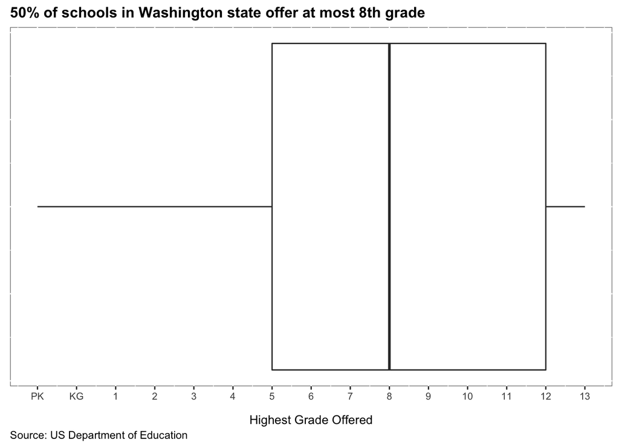

```r
box3 = box2 + labs(title = "50% of schools in Washington state offer at most 8th grade",
                   y = "Highest Grade Offered",
                   caption = "Source: US Department of Education") +
            theme(panel.background = element_rect(fill = "white", colour = "grey50")) +
            theme(axis.text.y = element_blank()) +
            theme(axis.ticks.y = element_blank())

box4 = box3 + theme(plot.title = element_text(size = 12, face = "bold"),
                    axis.text.x = element_text(size = 8),
                    axis.title.x = element_text(size = 10, vjust = -2),
                    plot.caption = element_text(hjust = 0, vjust = -1))

box4
```

### Counting

Exercise:  
Make a histogram for the variable FREE LUNCH, and make sure it has all the right elements, and get rid of unnecessary elements.

```r
summary(eduwa$Free.Lunch)
```

```
##    Min. 1st Qu.  Median    Mean 3rd Qu.    Max.    NA's
##     0.0    52.0   140.0   179.4   245.2  1766.0     131
```

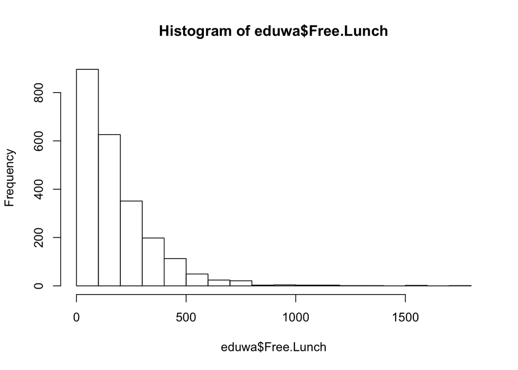

```r
eduwaFL <- eduwa[complete.cases(eduwa$Free.Lunch),]
datahistFL <- hist(eduwa$Free.Lunch)
```

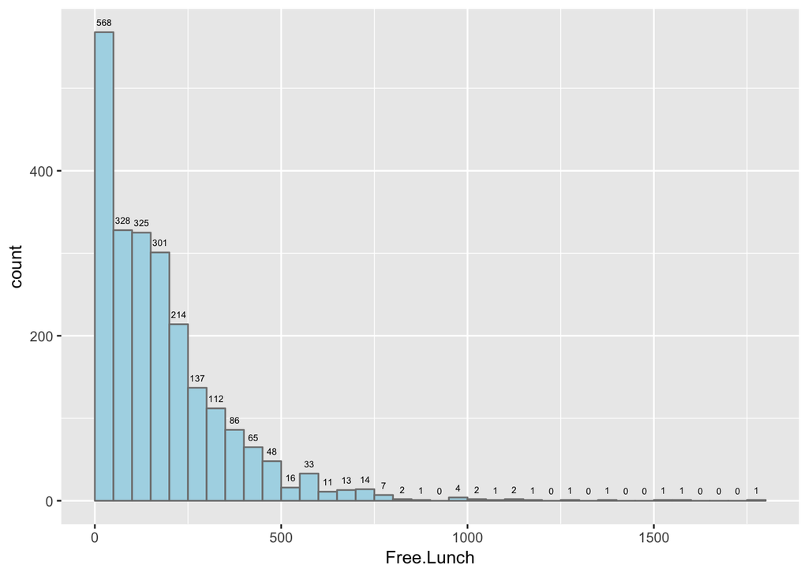

```r
baseFL = ggplot(eduwaFL, aes(x = Free.Lunch))
histFL = baseFL + geom_histogram(binwidth = 50, boundary = 0, fill = "lightblue", color = "grey50")
histFL = histFL + stat_bin(binwidth = 50, aes(label=..count..),
                  geom = "text",boundary = 0,vjust=-1, size = 2)

histFL
```

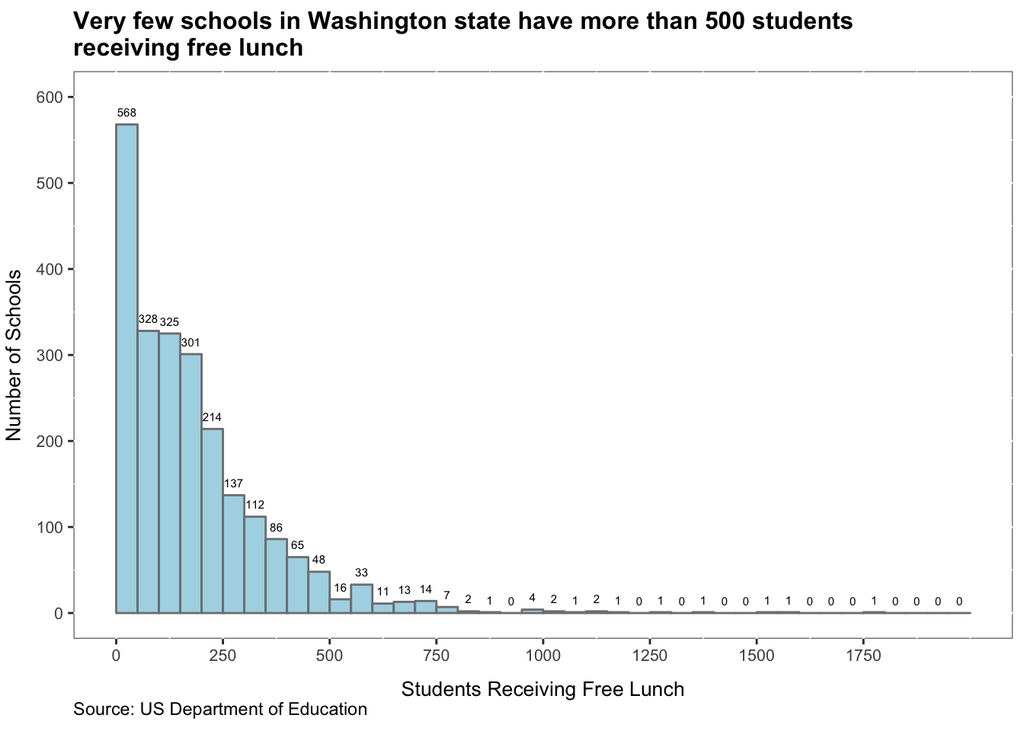

```r
titleFL2 = "Very few schools in Washington state have more than 500 students \nreceiving free lunch"

histFL2 = histFL + labs(title = titleFL2,
                        x = "Students Receiving Free Lunch",
                        y = "Number of Schools",
                        caption = "Source: US Department of Education")

histFL3 = histFL2 + theme(panel.background = element_rect(fill = "white", colour = "grey50"),
                          plot.title = element_text(size = 12, face = "bold"),
                          axis.title = element_text(size = 10),
                          axis.text = element_text(size = 8),
                          plot.caption = element_text(hjust = 0),
                          axis.title.x = element_text(vjust = -1),
                          axis.title.y = element_text(vjust = 2))

histFL4 = histFL3 + scale_x_continuous(breaks = c(0,250,500,750,1000,1250,1500,1750), limits = c(0,2000)) +
                    scale_y_continuous(breaks = c(0,100,200,300,400,500,600), limits = c(0,600))

histFL4
```

### Measurement

```r
# strategy 2:
eduwa4=eduwa[complete.cases(eduwa$Student.Teacher.Ratio),]

tapply(eduwa4$Student.Teacher.Ratio,
       eduwa4$County,
       mean)
```

```
##        Adams       Asotin       Benton       Chelan      Clallam
##     14.80769     19.11111     20.38947     18.65000     19.27600
##        Clark     Columbia      Cowlitz      Douglas        Ferry
##     19.19744     11.30000     20.38974     16.47222     16.82727
##     Franklin     Garfield        Grant Grays Harbor       Island
##     18.10323     17.35000     17.52449     16.33846     19.53000
##    Jefferson         King       Kitsap     Kittitas    Klickitat
##     16.57857     18.80203     19.24030     18.93529     14.82632
##        Lewis      Lincoln        Mason     Okanogan      Pacific
##     18.93902     11.56000     16.76316     19.73226     22.39375
## Pend Oreille       Pierce     San Juan       Skagit     Skamania
##     15.47778     18.77931     15.90000     22.47209     16.37000
##    Snohomish      Spokane      Stevens     Thurston    Wahkiakum
##     20.49239     18.13542     19.61765     19.29231     18.15000
##  Walla Walla      Whatcom      Whitman       Yakima
##     15.55652     23.77213     13.27083     19.97500
```

```r
# keeping strategy 2:
meanValues=tapply(eduwa4$Student.Teacher.Ratio,
                  eduwa4$County,
                  mean)
```

```r
summary(meanValues)
```

```
##    Min. 1st Qu.  Median    Mean 3rd Qu.    Max.
##   11.30   16.42   18.65   17.96   19.41   23.77
```

Exercise:  
Do some research and make a histogram and a density plot using ggplot for the variable we just used above.

```r
stratiodf <- as.data.frame(meanValues)
stratiodf$county <- rownames(stratiodf)
rownames(stratiodf) <- NULL
head(stratiodf)
```

```
##   meanValues  county
## 1   14.80769   Adams
## 2   19.11111  Asotin
## 3   20.38947  Benton
## 4   18.65000  Chelan
## 5   19.27600 Clallam
## 6   19.19744   Clark
```

```r
summary(stratiodf$meanValues)
```

```
##    Min. 1st Qu.  Median    Mean 3rd Qu.    Max.
##   11.30   16.42   18.65   17.96   19.41   23.77
```

```r
meanST <- mean(stratiodf$meanValues)
meanST
```

```
## [1] 17.95639
```

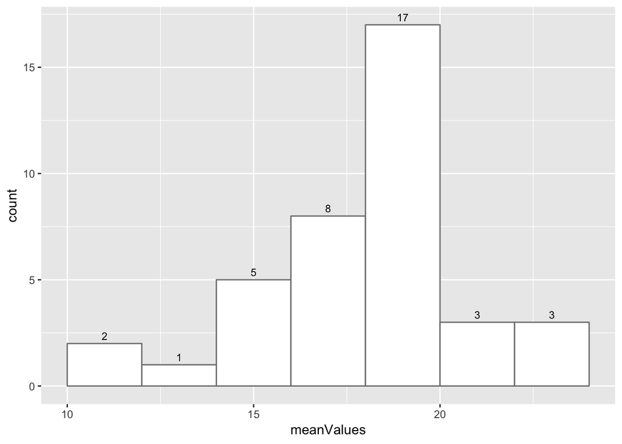

```r
baseST = ggplot(stratiodf, aes(x = meanValues))
histST = baseST + geom_histogram(binwidth = 2, boundary = 0, fill = "white", color = "grey50")
histST = histST + stat_bin(binwidth = 2, aes(label=..count..),
                  geom = "text",boundary = 0,vjust=-0.5, size = 3)

histST
```

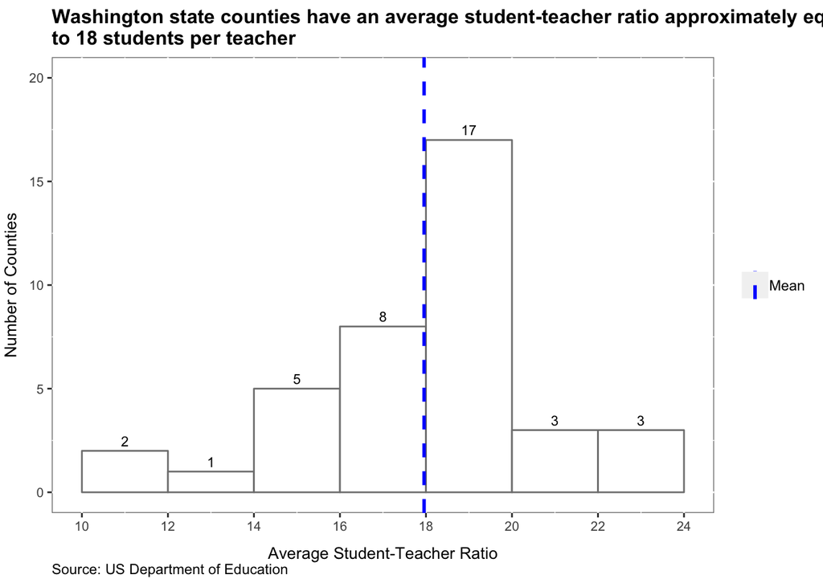

```r
titleST2 = "Washington state counties have an average student-teacher ratio approximately equal \nto 18 students per teacher"

histST2 = histST + labs(title = titleST2,
                        x = "Average Student-Teacher Ratio",
                        y = "Number of Counties",
                        caption = "Source: US Department of Education")

histST3 = histST2 + theme(panel.background = element_rect(fill = "white", colour = "grey50"),
                          plot.title = element_text(size = 12, face = "bold"),
                          axis.title = element_text(size = 10),
                          axis.text = element_text(size = 8),
                          plot.caption = element_text(hjust = 0),
                          axis.title.x = element_text(vjust = -1),
                          axis.title.y = element_text(vjust = 2))

histST4 = histST3 + scale_x_continuous(breaks = c(10,12,14,16,18,20,22,24), limits = c(10,24)) +
                    scale_y_continuous(breaks = c(0,5,10,15,20), limits = c(0,20))

histST5 = histST4 + geom_vline(aes(xintercept = mean(stratiodf$meanValues), color="mean"),
                               size = 1, linetype = "dashed")

histST6 = histST5 + theme(legend.title = element_blank()) +
                    scale_color_manual(labels = c("Mean"), values = c("blue"))

histST6
```

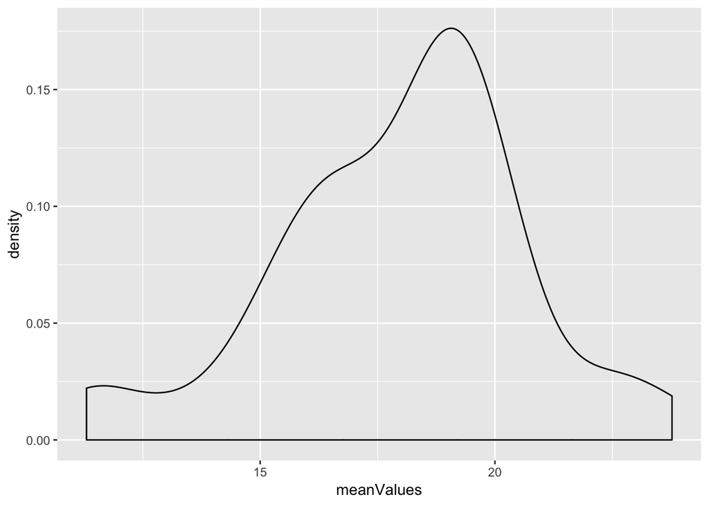

```r
baseSTden <- ggplot(stratiodf, aes(x = meanValues))

denST <- baseSTden + geom_density()

denST
```

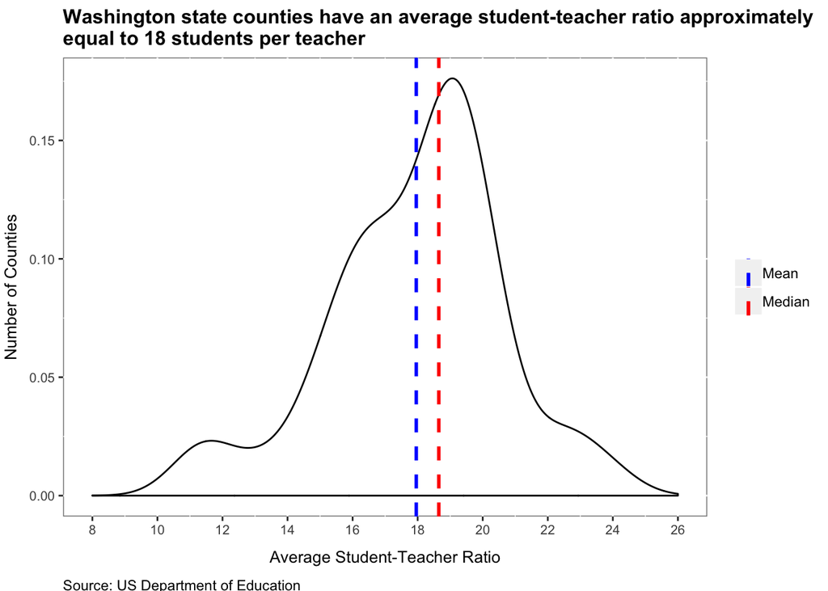

```r
titleden = "Washington state counties have an average student-teacher ratio approximately \nequal to 18 students per teacher"

denST2 = denST + labs(title = titleden,
                        x = "Average Student-Teacher Ratio",
                        y = "Number of Counties",
                        caption = "Source: US Department of Education")

denST3 = denST2 + theme(panel.background = element_rect(fill = "white", colour = "grey50"),
                          plot.title = element_text(size = 12, face = "bold"),
                          axis.title = element_text(size = 10),
                          axis.text = element_text(size = 8),
                          plot.caption = element_text(hjust = 0, vjust = -2),
                          axis.title.x = element_text(vjust = -1),
                          axis.title.y = element_text(vjust = 2))

denST4 = denST3 + scale_x_continuous(breaks = c(8,10,12,14,16,18,20,22,24,26), limits = c(8,26))

denST5 = denST4 + geom_vline(aes(xintercept = mean(stratiodf$meanValues), color="mean"),
                               size = 1, linetype = "dashed") +
                  geom_vline(aes(xintercept = median(stratiodf$meanValues), color="median"),
                               size = 1, linetype = "dashed", show.legend = TRUE)

denST6 = denST5 + theme(legend.title = element_blank()) +
                  scale_color_manual(labels = c("Mean", "Median"), values = c("blue", "red"))

denST6
```

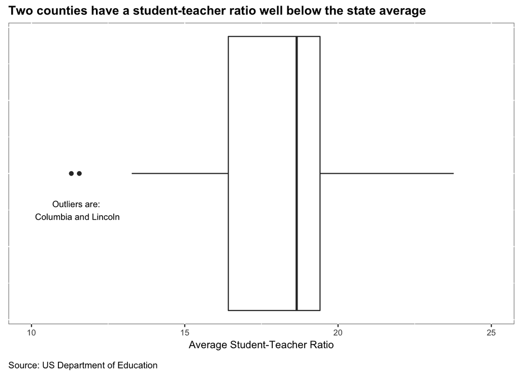

```r
boxST = ggplot(stratiodf, aes(y=meanValues, z="Test"))

boxST = boxST + geom_boxplot() + coord_flip() + scale_y_continuous(breaks = c(10,15,20,25),
                                                                   limits = c(10,25))

boxST2 = boxST + labs(title = "Two counties have a student-teacher ratio well below the state average",
                   y = "Average Student-Teacher Ratio",
                   caption = "Source: US Department of Education") +
                   theme(panel.background = element_rect(fill = "white", colour = "grey50")) +
                   theme(axis.text.y = element_blank()) +
                   theme(axis.ticks.y = element_blank()) +
                   theme(axis.title.y = element_blank())

boxST3 = boxST2 + theme(plot.title = element_text(size = 12, face = "bold"),
                    axis.text.x = element_text(size = 8),
                    axis.title.x = element_text(size = 10),
                    plot.caption = element_text(hjust = 0, vjust = -1))

boxST4 = boxST3 + annotate("text", x = -0.1, y = 11.5, label = "Outliers are: \nColumbia and Lincoln", size = 3)

boxST4
```